# Alignment CDF Documentation: Code accompaniment to the report entitled ‘Visualization, Quantification and Alignment of Spectral Drift in Population Scale Untargeted Metabolomics Data’

Mir Henglin et al.

December 23, 2016

©2017 JD Watrous, M Henglin, B Claggett, S Cheng, M Jain, Brigham and Women’s Hospital and UCSD, all rights reserved.

citation: TBA

```r
library(magrittr)
library(purrr)
library(dplyr)
library(readr)
library(ggplot2)
library(tidyr)
```

After applying our correction, we needed an approach to assess performance relative to baseline and other corrective models. There are many metrics of improvement that we could have considered. The number of perfectly aligned metabolites, the number of metabolites under some threshold of missingness across the sample, how well a certain cohort of metabolites improve, etc. In the end, we selected an approach that would take many of these metrics into consideration simultaneously.

```r
makeDset <- function() {
  plate <-
    1:10

  well <-
    1:10

  metaboliteID <-
    runif(10, 100, 900)

  while (length(unique(metaboliteID)) != length(metaboliteID)) {
    metaboliteID <-
      runif(10, 100, 900)
  }

  dat <-
    expand.grid(plate, well, metaboliteID) %>%
    setNames(c('plate', 'well', 'metaboliteID'))


  dat %<>%
    mutate(plateWellID = paste0(plate, '_', well),
           value = runif(n(), 1000, 1000000)) %>%
    tbl_df()

  return(dat)
}

d1 <- makeDset() %>%
  mutate(method = 'Uncorrected')

d2 <- makeDset() %>%
  mutate(method = 'Corrected')

dat <-
  bind_rows(d1, d2)
dat
```

```
## # A tibble: 2,000 × 6
##    plate  well metaboliteID plateWellID      value      method
##    <int> <int>        <dbl>       <chr>      <dbl>       <chr>
## 1      1     1     219.5141         1_1 241097.714 Uncorrected
## 2      2     1     219.5141         2_1   1834.639 Uncorrected
## 3      3     1     219.5141         3_1 930943.618 Uncorrected
## 4      4     1     219.5141         4_1 552603.530 Uncorrected
## 5      5     1     219.5141         5_1 321172.037 Uncorrected
## 6      6     1     219.5141         6_1  26699.103 Uncorrected
## 7      7     1     219.5141         7_1  15496.477 Uncorrected
## 8      8     1     219.5141         8_1 314878.985 Uncorrected
## 9      9     1     219.5141         9_1  98052.887 Uncorrected
## 10    10     1     219.5141        10_1 596205.092 Uncorrected
## # ... with 1,990 more rows
```

For our sample data, the columns are:

- metaboliteID
  - ID representing a unique measured metabolite.
- plateWellID
  - ID representing a sample in which metabolites were measured.
- plate, well
  - The plate and well that a sample was measured in.
- value
  - The peak abundance measured in a sample.
- method
  - We generated a dataset with the above columns for the uncorrected data and data after applying a correction algorithm. Those datasets were stacked togehter, with this column identifying the dataset each row belongs to.

Once again, this is data generated only to give an idea of what our data looks like. It is not used beyond this point.

Our samples were measured in plates of 96 wells. We said that a metabolite was misaligned for a plate if it is missing for all wells in that plate. For each metabolite, we calculated the percentage of plates that it was missing in, and then counted the number of metabolites at each value of % misalignment. We can then calculate a cumulative sum to get the number of metabolites that are X% misaligned or better. We also chose to only perform this calculation for up to 50% missingness, as using metabolites that were majority missing to evaluate performance of an alignment algorithm is impractical. After calculating these values, we have a CDF and we can calculate the area under the curve. The AUC was our most important metric in evaluating model performance.

```r
# Perc Misaligned cdf -------------------------------------------------
maxPerc <- 0.5

misalign <-
  dat %>%
  # label any plates where a metaboliteID is totally missing
  group_by(method, metaboliteID, plate) %>%
  summarise(misaligned = all(value == 0)) %>%
  ungroup() %>%
  # Calculate % of plates totally missing
  group_by(method, metaboliteID) %>%
  summarise(misaligned = mean(misaligned)) %>%
  ungroup() %>%
  # Count the number of metaboliteIDs that are at any given misalignment %
  group_by(method, misaligned) %>%
  summarise(n = n()) %>%
  ungroup() %>%
  # Only include metabolites that are 50% missing or less
  filter(misaligned <= maxPerc) %>%
  # Calculate the cumulative count of metabolites that are 5% misaligned or better.
  group_by(method) %>%
  mutate(cumMisaligned = cumsum(n)) %>%
  ungroup()

misalign
```

```
## # A tibble: 51 × 4
##          method misaligned     n cumMisaligned
##           <chr>      <dbl> <int>         <int>
## 1  ComplexModel 0.00000000   661           661
## 2  ComplexModel 0.03030303   139           800
## 3  ComplexModel 0.06060606   116           916
## 4  ComplexModel 0.09090909    92          1008
## 5  ComplexModel 0.12121212    74          1082
## 6  ComplexModel 0.15151515    80          1162
## 7  ComplexModel 0.18181818    59          1221
## 8  ComplexModel 0.21212121   102          1323
## 9  ComplexModel 0.24242424    72          1395
## 10 ComplexModel 0.27272727    88          1483
## # ... with 41 more rows
```

Here we calculate the area under our CDF by multiplying the width and height of each ‘step’ in the CDF and summing them together. We format it with x and y values so it can be added as a label to our plot later.

```r
auc <-
  misalign %>%
  group_by(method) %>%
  mutate(width = c(diff(misaligned), maxPerc - max(misaligned))) %>%
  mutate(auc = width * cumMisaligned) %>%
  summarise(auc = sum(auc),
            y = max(cumMisaligned)) %>%
  mutate(label = paste('AUCDF', round(auc, 1)),
         x = maxPerc) %>%
  select(method, label, x, y)

auc
```

```
## # A tibble: 3 × 4
##         method       label     x     y
##          <chr>       <chr> <dbl> <int>
## 1 ComplexModel AUCDF 694.7   0.5  2150
## 2     Original AUCDF 313.4   0.5  1737
## 3  SimpleModel AUCDF 719.4   0.5  2181
```

Though AUC is our most important metric, we also consider the number of metabolites that have no missing plates. We calculate and format for labeling plots later here.

```r
nMetabolites <-
  dat %>%
  group_by(method) %>%
  summarise(nMetabolite = length(unique(metaboliteID)))

perfaligned <-
  misalign %>%
  left_join(nMetabolites, by = 'method') %>%
  filter(misaligned == 0) %>%
  group_by(method) %>%
  summarise(label = cumMisaligned / nMetabolite,
            naligned = label * nMetabolite,
            x = -0.00,
            y = naligned) %>%
  mutate() %>%
  mutate(label = paste('No Misalignment Percentage:', round(label, 2))) %>%
  ungroup() %>%
  select(method, label, x, y)

perfaligned
```

```
## # A tibble: 3 × 4
##         method                            label     x     y
##          <chr>                            <chr> <dbl> <dbl>
## 1 ComplexModel No Misalignment Percentage: 0.09     0   661
## 2     Original    No Misalignment Percentage: 0     0    91
## 3  SimpleModel No Misalignment Percentage: 0.09     0   700
```

The CDF step function needs an additional value at the end so that it ends on a horizontal segment, not a vertical one. That is that the ‘tail’ is for.

```r
cdftails <-
  misalign %>%
  group_by(method) %>%
  summarise(cumMisaligned = max(cumMisaligned)) %>%
  mutate(misaligned = maxPerc)

misalign %<>% full_join(cdftails, by = c("method", "misaligned", "cumMisaligned"))
```

Now we plot, one with labels, and one without to make it easier to see the graph.

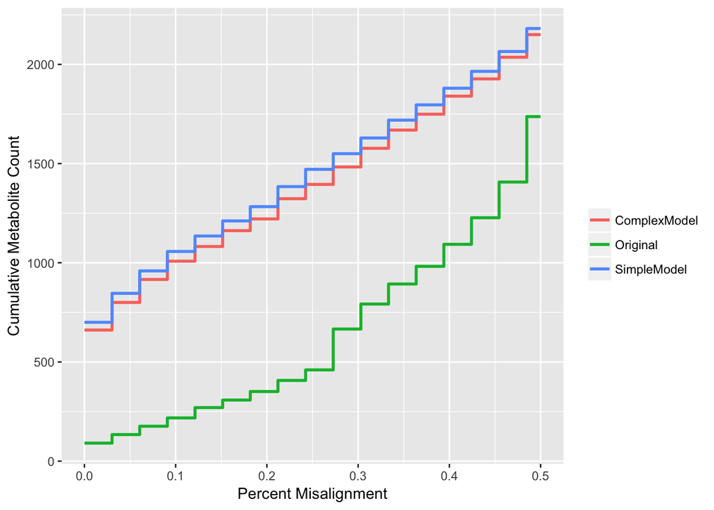

```r
plotText <-
  rbind(perfaligned, auc)

p <-
  misalign %>%
  ggplot(aes(colour = method)) +
  geom_step(aes(x = misaligned, y = cumMisaligned), direction = 'hv', size = 1) +
  ylab('Cumulative Metabolite Count') +
  xlab('Percent Misalignment') +
  scale_colour_discrete('')

p
```

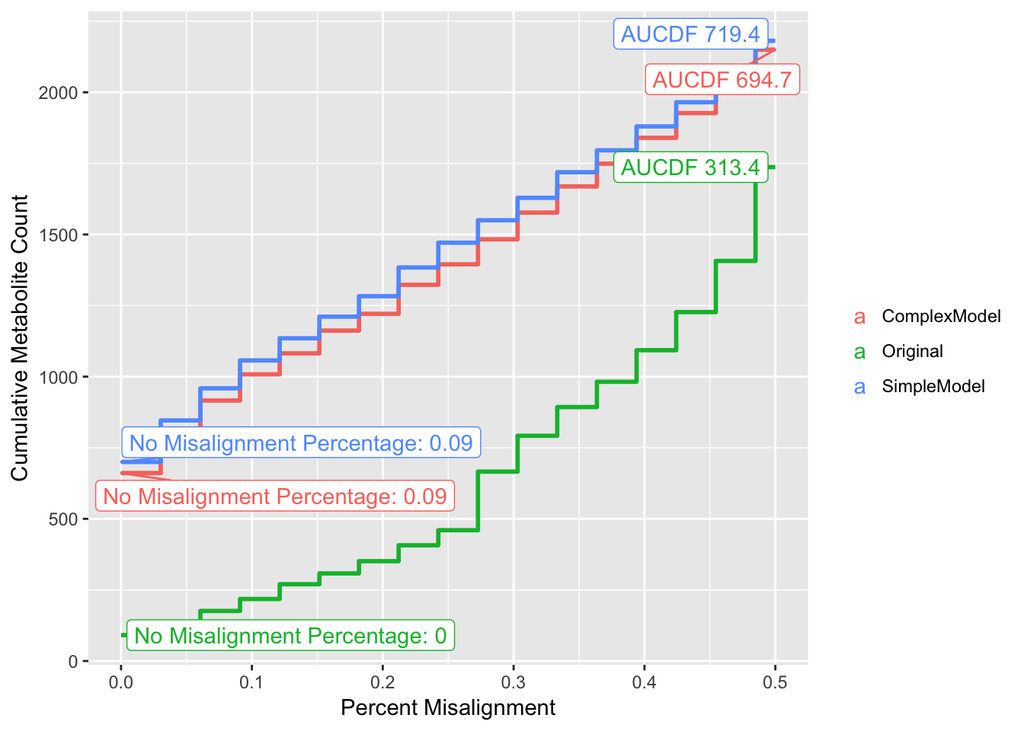

```r
p +
  ggrepel::geom_label_repel(data = plotText, aes(label = label, x = x, y = y))
```

We see from our graphs that the data corrected with the simpler model, and with the more complex model, both outperform the uncorrected data. There are many more metabolites that are not missing across plates, and many more metabolites that are 50% misaligned or less. The simpler and more complex models seem to have very similar performance overall, with the simpler model having slightly greater AUC. In this case, we would elect to use the more parsimonious model going forward.